# EIS 2026 Information Sources

#### Never-seekers only

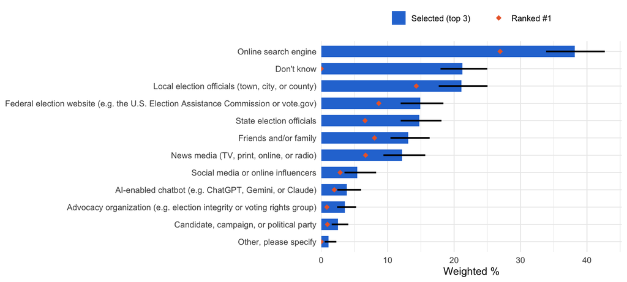

n = 743

**By party ID — selected**

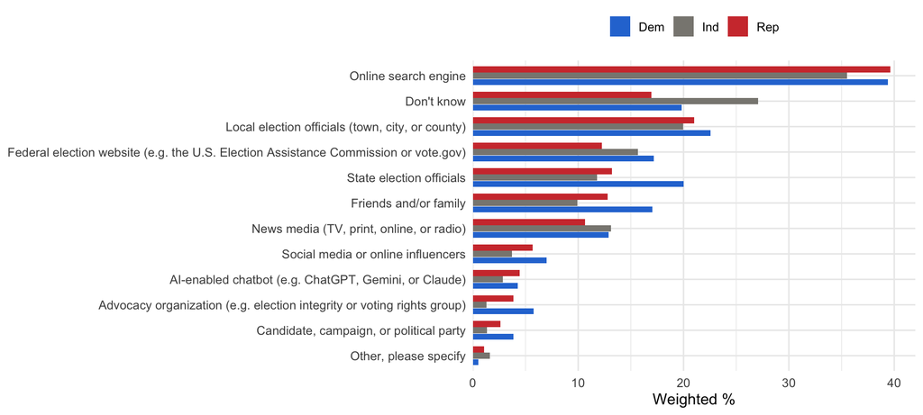

**By party ID — ranked #1**

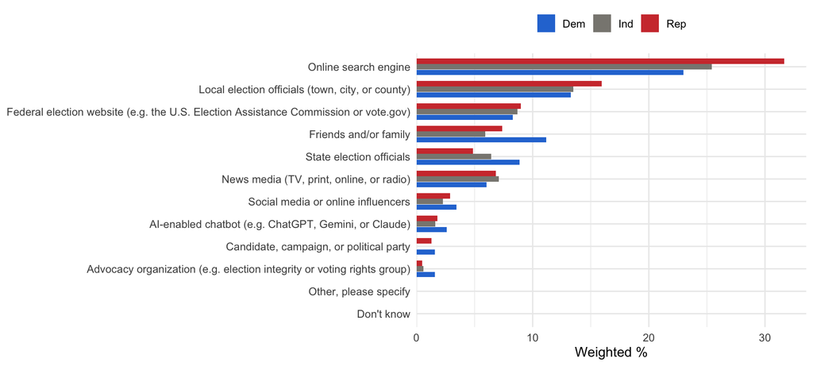

### Drill-downs (everyone included)

#### Contact mode (local/state election officials)

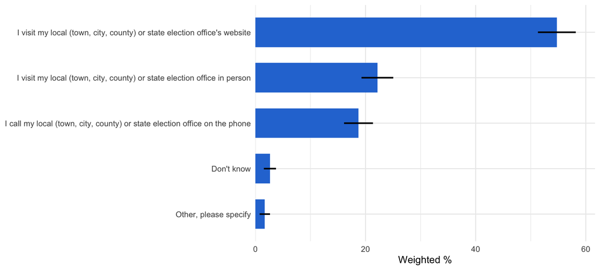

n = 1,134

**By party ID**

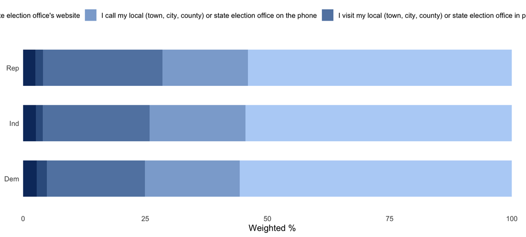

#### Social media platform

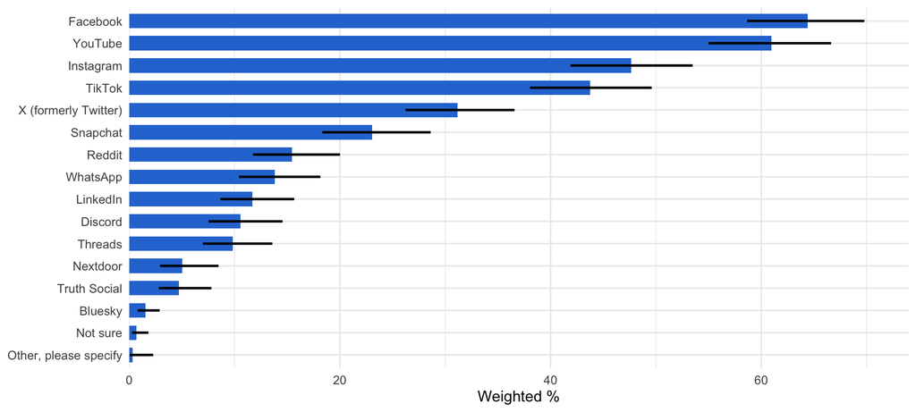

n = 451

**By party ID**

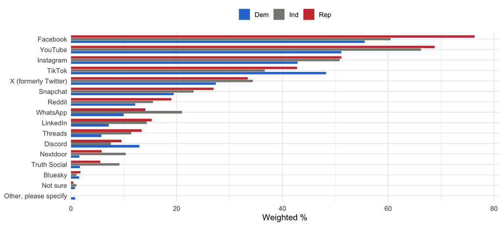

#### AI chatbot

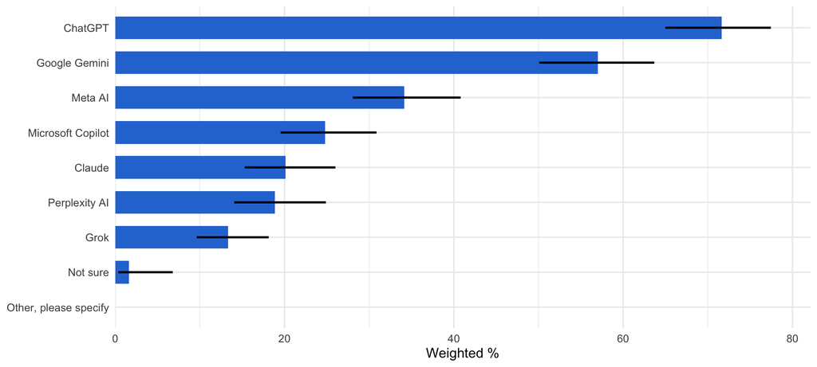

n = 309

**By party ID**

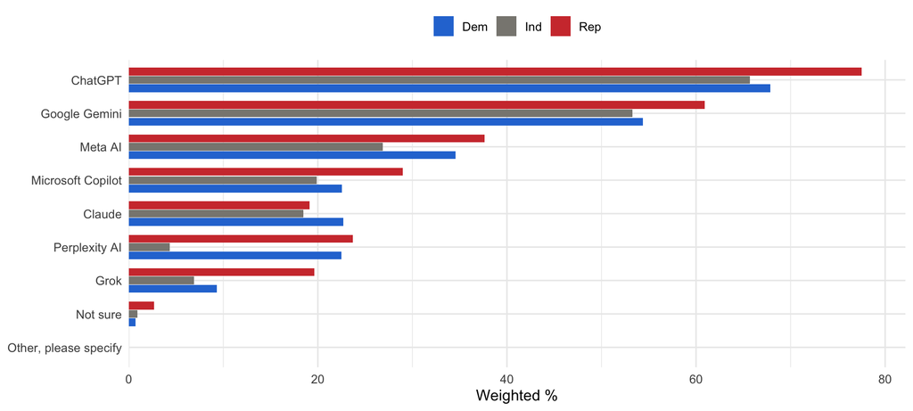

## Who Won an Election

### Which sources

#### Exclude never-seekers

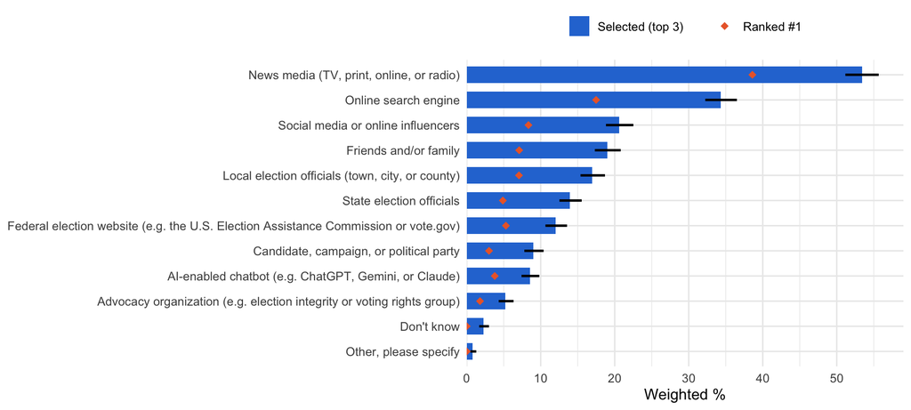

n = 2,813

**By party ID — selected**

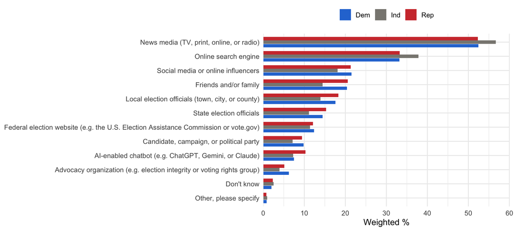

**By party ID — ranked #1**

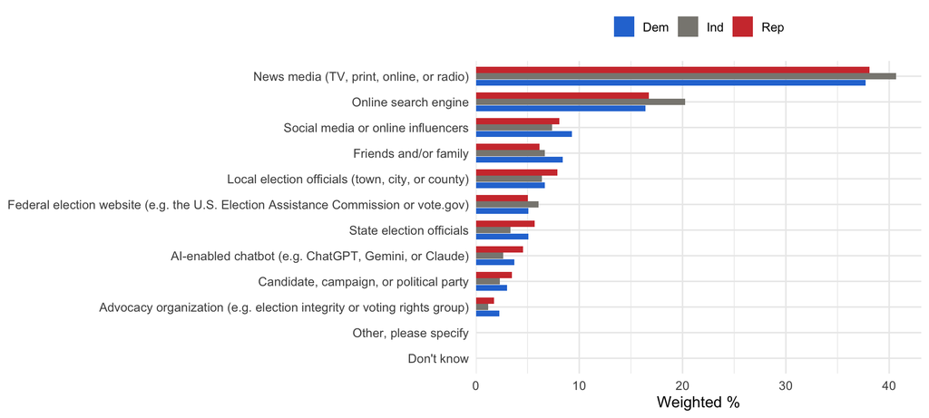

#### Include everyone

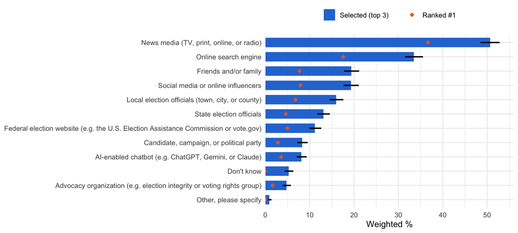

n = 3,144

**By party ID — selected**

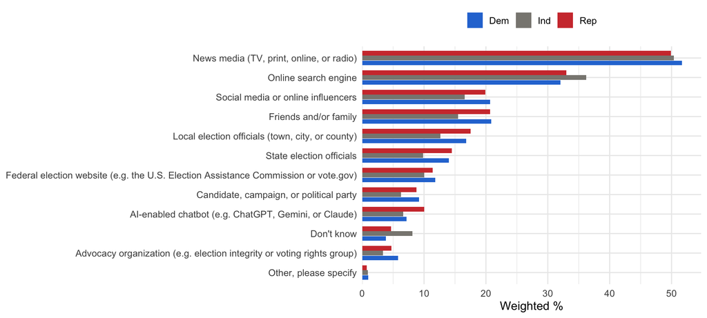

**By party ID — ranked #1**

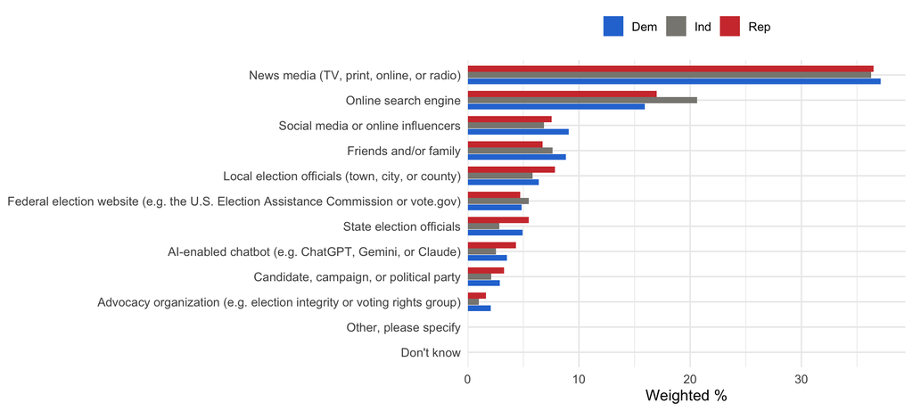

#### Never-seekers only

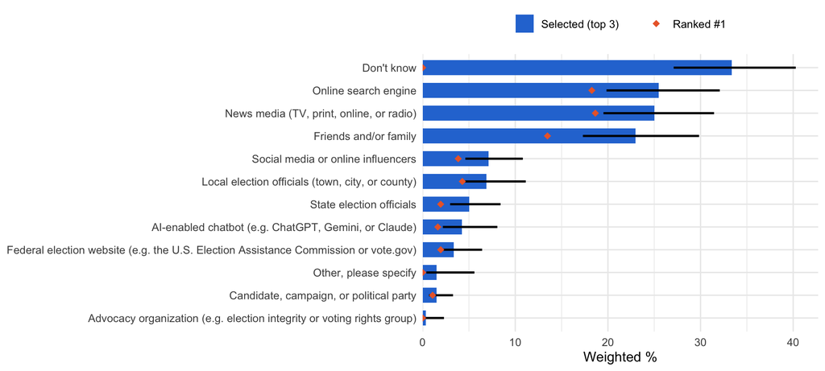

n = 331

**By party ID — selected**

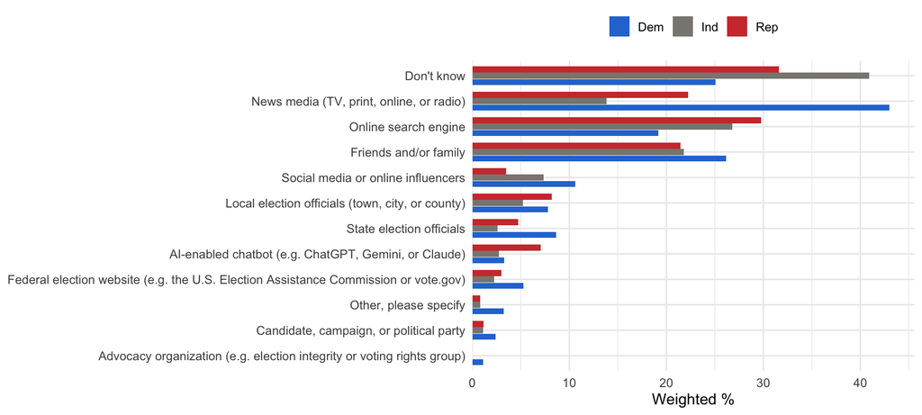

**By party ID — ranked #1**

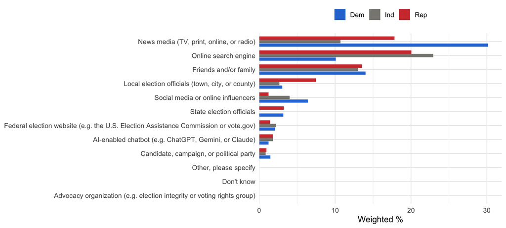

### Drill-downs (everyone included)

#### Contact mode (local/state election officials)

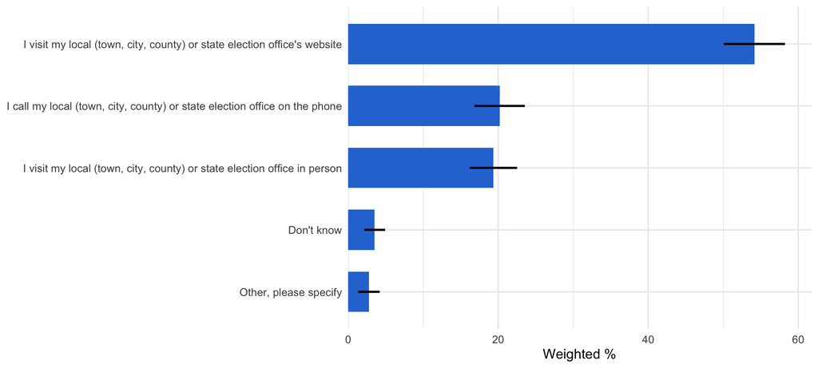

n = 797

**By party ID**

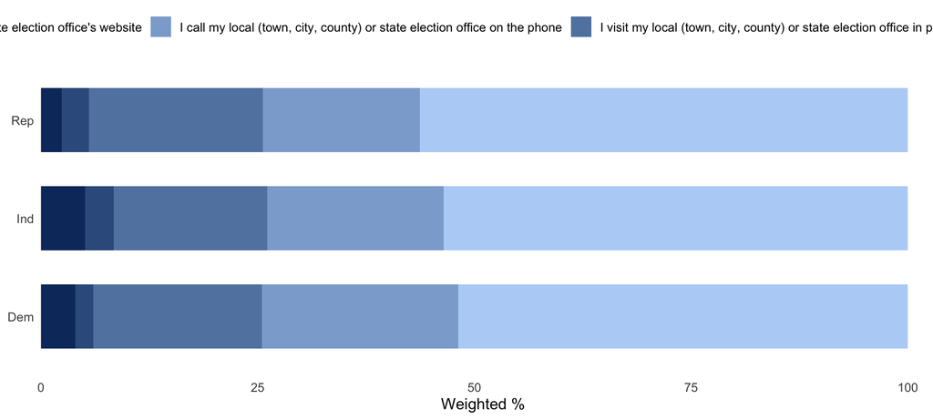

#### Social media platform

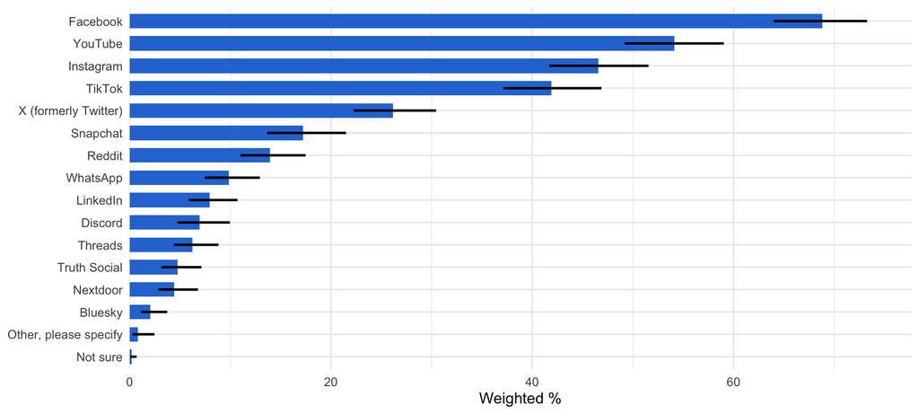

n = 605

**By party ID**

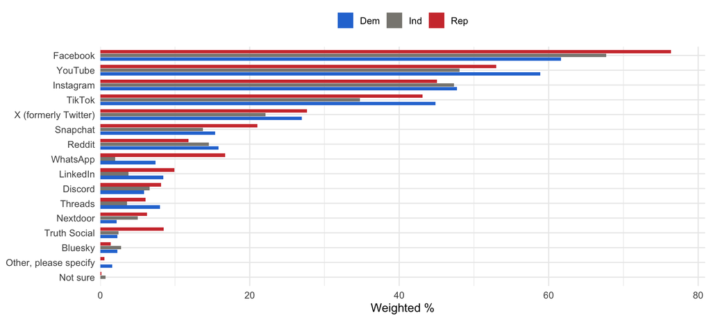

#### AI chatbot

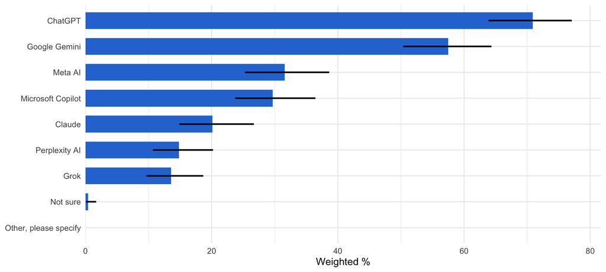

n = 272

**By party ID**

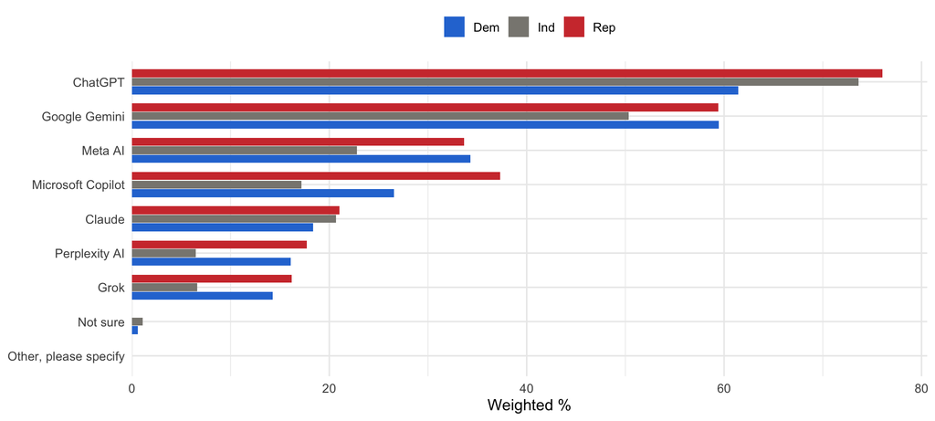

# Part 3: 2026 vs. 2024 Trend

Scoped to the election-information-source questions covered in Parts 1-2. For every other survey topic (right direction, AI attitudes, confidence, concern, etc.), see `eis_2026_05_trend_comparison_report.Rmd`. All estimates below use `weight_common`.

## Main election-news sources (BPC2)

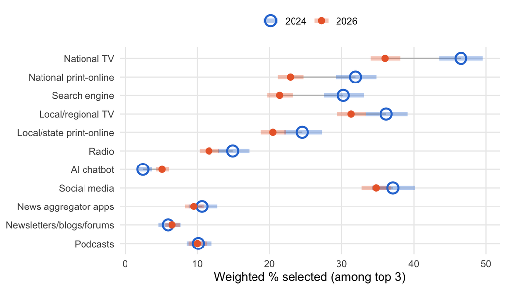

**New in 2026:** 22.4% (95% CI 20.7-24.2) of 2026 respondents selected “Friends and/or family” as a main news source — this option did not exist in the 2024 survey. There is no item in the 2024 survey that was dropped from this battery.

## Registering and voting

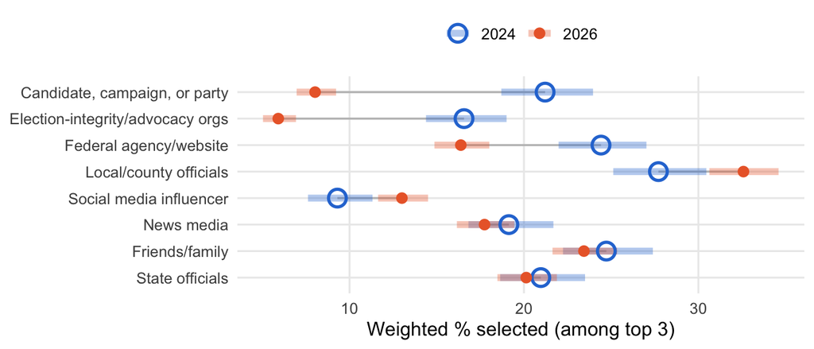

**New in 2026 (no 2024 counterpart)**

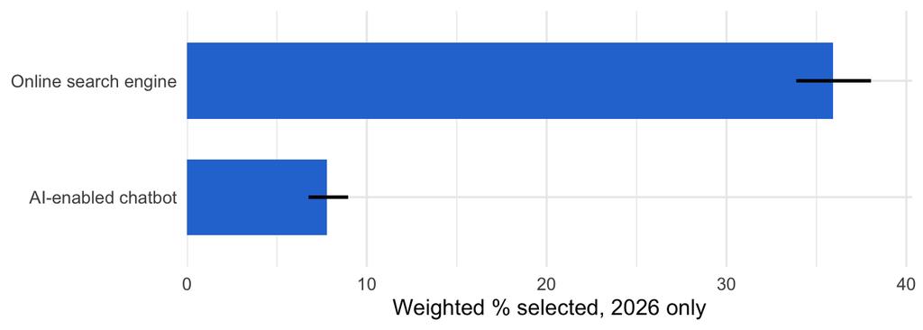

**Dropped after 2024 (no 2026 counterpart)**

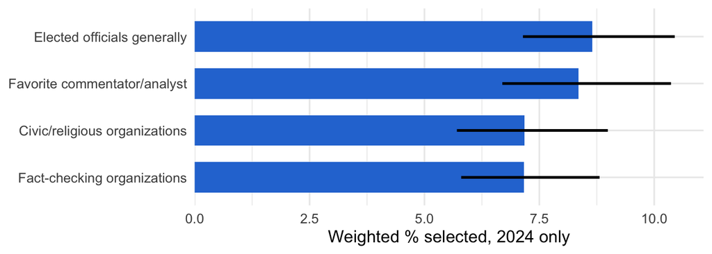

## How elections are run

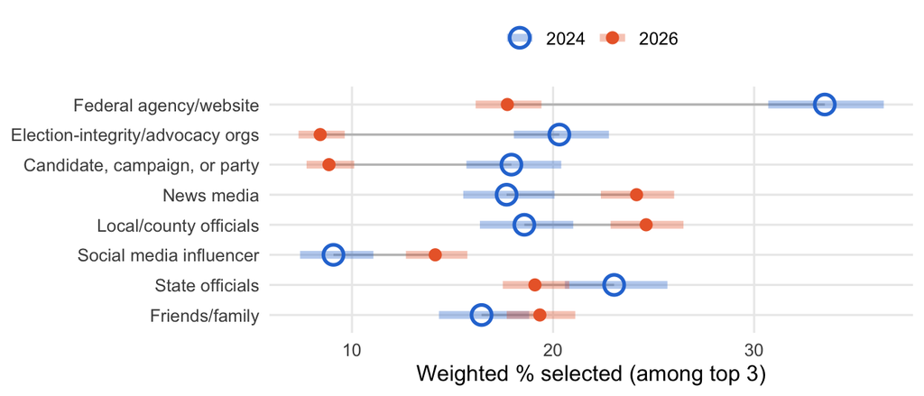

**New in 2026 (no 2024 counterpart)**

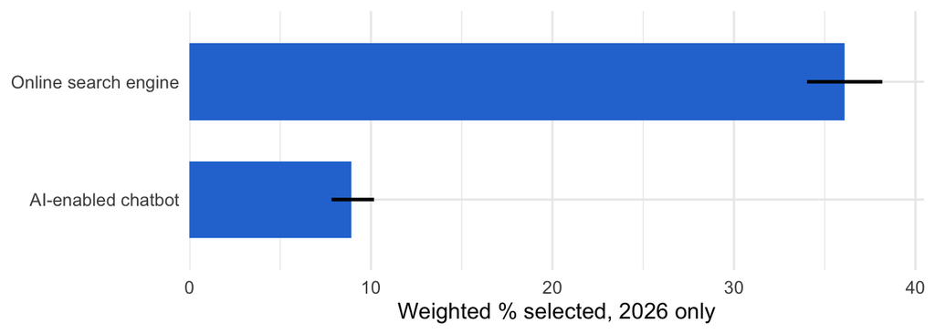

**Dropped after 2024 (no 2026 counterpart)**

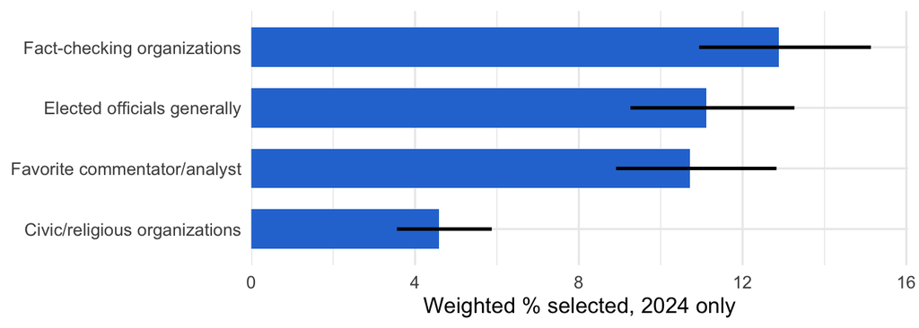

## Who won

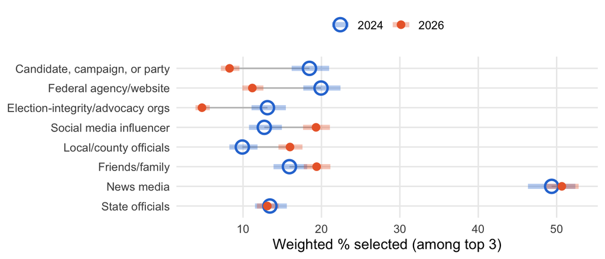

**New in 2026 (no 2024 counterpart)**

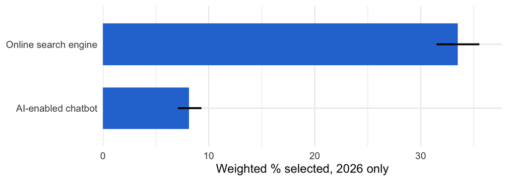

**Dropped after 2024 (no 2026 counterpart)**

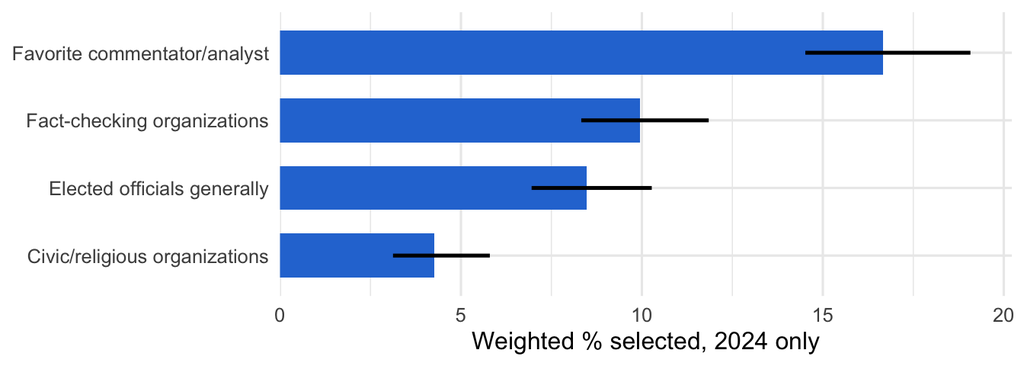